# OpenFlights Data Analysis

Team Members: Nina, Lucas, Brandon

## Research Topic

*This project explores global air travel using the OpenFlights datasets. We aim to understand the structure of airline networks, geographic coverage, and operational characteristics by examining data on airlines, airports, routes, countries, and planes.*

## Team Members

- **Nina**
- **Lucas**
- **Brandon**

## Data

### Description of the Data Set

- **Airlines Dataset:**  
  Contains information on 5,888 airlines, including unique identifiers, names, aliases, IATA/ICAO codes, callsigns, country of operation, and operational status.
- **Airports Dataset:**  
  Includes over 10,000 entries for airports, train stations, and ferry terminals worldwide. Key variables include unique IDs, names, cities, countries, codes, coordinates, altitude, time zone, DST rules, and source details.
- **Countries Dataset:**  
  Provides country names along with their ISO 2-letter and 3-letter codes.
- **Planes Dataset:**  
  Details various aircraft types with names, IATA equipment codes, and ICAO equipment codes.
- **Routes Dataset:**  
  Contains historical route information (as of June 2014) with 67,663 routes covering 3,321 airports and 548 airlines. Variables include airline codes and IDs, source and destination airport codes/IDs, codeshare indicators, number of stops, and equipment codes.

## Data Loading and First Data Cleaning Steps

Below, we load the datasets, assign meaningful column names, and perform basic cleaning such as removing obvious missing values and standardizing column names.

```r
library(tidyverse)
library(janitor)
```

```r
#Define file paths
airlines_path <- "../data/airlines.dat"
airports_path <- "../data/airports.dat"
countries_path <- "../data/countries.dat"
planes_path <- "../data/planes.dat"
routes_path <- "../data/routes.dat"

airlines <- read_csv(airlines_path, col_names = FALSE, show_col_types = FALSE) %>%
  set_names(c("airline_id", "name", "alias", "iata", "icao", "callsign", "country", "active")) %>%
  clean_names()

airports <- read_csv(airports_path, col_names = FALSE, show_col_types = FALSE) %>%
  set_names(c("airport_id", "name", "city", "country", "iata", "icao",
              "latitude", "longitude", "altitude", "timezone", "dst",
              "olson_timezone", "type", "source")) %>%
  clean_names()

countries <- read_csv(countries_path, col_names = FALSE, show_col_types = FALSE) %>%
  set_names(c("country", "iso2", "iso3")) %>%
  clean_names()

planes <- read_csv(planes_path, col_names = FALSE, show_col_types = FALSE) %>%
  set_names(c("plane_name", "iata_equipment", "icao_equipment")) %>%
  clean_names()

routes <- read_csv(routes_path, col_names = FALSE, na = "\\N", show_col_types = FALSE) %>%
  set_names(c("airline", "airline_id", "source_airport", "source_airport_id",
              "destination_airport", "destination_airport_id", "codeshare",
              "stops", "equipment")) %>%
  clean_names()
```

```r
# Clean Airlines: Replace "\\N" with NA in character columns, convert types, keep active airlines
airlines_clean <- airlines %>%
  mutate(across(where(is.character), ~ na_if(.x, "\\N")),
         airline_id = as.integer(airline_id)) %>%
  filter(!is.na(airline_id), active == "Y") %>%
  distinct()

# Clean Airports: Replace "\\N" with NA in character columns, convert types, remove invalid coords/codes
airports_clean <- airports %>%
  mutate(across(where(is.character), ~ na_if(.x, "\\N")),
         airport_id = as.integer(airport_id),
         latitude = as.numeric(latitude),
         longitude = as.numeric(longitude),
         altitude = as.numeric(altitude),
         timezone = as.numeric(timezone)) %>%
  filter(!is.na(latitude), !is.na(longitude), !is.na(iata), !is.na(icao)) %>%
  distinct()

# Clean Routes: Replace "\\N" with NA in character columns, convert types, keep direct flights
routes_clean <- routes %>%
  mutate(across(where(is.character), ~ na_if(.x, "\\N")),
         airline_id = as.integer(airline_id),
         source_airport_id = as.integer(source_airport_id),
         destination_airport_id = as.integer(destination_airport_id),
         stops = as.integer(stops)) %>%
  filter(!is.na(source_airport_id), !is.na(destination_airport_id)) %>%
  filter(stops == 0) %>%
  distinct()

# Clean Countries: Replace "\\N" with NA in character columns, remove rows with missing country
countries_clean <- countries %>%
  mutate(across(where(is.character), ~ na_if(.x, "\\N"))) %>%
  filter(!is.na(country)) %>%
  distinct()

# Clean Planes: Replace "\\N" with NA in character columns, keep rows with at least one equipment code
planes_clean <- planes %>%
  mutate(across(where(is.character), ~ na_if(.x, "\\N"))) %>%
  filter(!is.na(iata_equipment) | !is.na(icao_equipment)) %>%
  distinct()
```

```r
# Join routes with airline data and source/destination airport info
routes_joined <- routes_clean %>%
  # Join with airline information
  left_join(airlines_clean, by = "airline_id") %>%

  # Join with source airport (adds _src suffix)
  left_join(airports_clean,
            by = c("source_airport_id" = "airport_id"),
            suffix = c("", "_src")) %>%

  # Join with destination airport (adds _dst suffix)
  left_join(airports_clean,
            by = c("destination_airport_id" = "airport_id"),
            suffix = c("", "_dst"))
```

```r
glimpse(airlines_clean)
```

```
## Rows: 1,255
## Columns: 8
## $ airline_id <int> -1, 1, 3, 10, 13, 14, 21, 22, 24, 28, 29, 32, 35, 42, 55, 6…
## $ name       <chr> "Unknown", "Private flight", "1Time Airline", "40-Mile Air"…
## $ alias      <chr> NA, NA, NA, NA, NA, NA, NA, NA, NA, NA, NA, NA, NA, NA, NA,…
## $ iata       <chr> "-", "-", "1T", "Q5", "AN", "1B", "ZI", "AQ", "AA", "OZ", "…
## $ icao       <chr> "N/A", "N/A", "RNX", "MLA", "AAA", NA, "AAF", "AAH", "AAL",…
## $ callsign   <chr> NA, NA, "NEXTIME", "MILE-AIR", "ANSETT", NA, "AIGLE AZUR", …
## $ country    <chr> NA, NA, "South Africa", "United States", "Australia", "Sing…
## $ active     <chr> "Y", "Y", "Y", "Y", "Y", "Y", "Y", "Y", "Y", "Y", "Y", "Y",…
```

```r
head(airlines_clean)
```

```
## # A tibble: 6 × 8
##   airline_id name                 alias iata  icao  callsign country      active
##        <int> <chr>                <chr> <chr> <chr> <chr>    <chr>        <chr>
## 1         -1 Unknown              <NA>  -     N/A   <NA>     <NA>         Y
## 2          1 Private flight       <NA>  -     N/A   <NA>     <NA>         Y
## 3          3 1Time Airline        <NA>  1T    RNX   NEXTIME  South Africa Y
## 4         10 40-Mile Air          <NA>  Q5    MLA   MILE-AIR United Stat… Y
## 5         13 Ansett Australia     <NA>  AN    AAA   ANSETT   Australia    Y
## 6         14 Abacus International <NA>  1B    <NA>  <NA>     Singapore    Y
```

```r
glimpse(airports_clean)
```

```
## Rows: 6,072
## Columns: 14
## $ airport_id     <int> 1, 2, 3, 4, 5, 6, 7, 8, 9, 10, 11, 12, 13, 14, 15, 16, …
## $ name           <chr> "Goroka Airport", "Madang Airport", "Mount Hagen Kagamu…
## $ city           <chr> "Goroka", "Madang", "Mount Hagen", "Nadzab", "Port More…
## $ country        <chr> "Papua New Guinea", "Papua New Guinea", "Papua New Guin…
## $ iata           <chr> "GKA", "MAG", "HGU", "LAE", "POM", "WWK", "UAK", "GOH",…
## $ icao           <chr> "AYGA", "AYMD", "AYMH", "AYNZ", "AYPY", "AYWK", "BGBW",…
## $ latitude       <dbl> -6.081690, -5.207080, -5.826790, -6.569803, -9.443380, …
## $ longitude      <dbl> 145.3920, 145.7890, 144.2960, 146.7260, 147.2200, 143.6…
## $ altitude       <dbl> 5282, 20, 5388, 239, 146, 19, 112, 283, 165, 251, 6, 76…
## $ timezone       <dbl> 10.0, 10.0, 10.0, 10.0, 10.0, 10.0, -3.0, -3.0, -3.0, -…
## $ dst            <chr> "U", "U", "U", "U", "U", "U", "E", "E", "E", "E", "N", …
## $ olson_timezone <chr> "Pacific/Port_Moresby", "Pacific/Port_Moresby", "Pacifi…
## $ type           <chr> "airport", "airport", "airport", "airport", "airport", …
## $ source         <chr> "OurAirports", "OurAirports", "OurAirports", "OurAirpor…
```

```r
head(airports_clean)
```

```
## # A tibble: 6 × 14
##   airport_id name          city  country iata  icao  latitude longitude altitude
##        <int> <chr>         <chr> <chr>   <chr> <chr>    <dbl>     <dbl>    <dbl>
## 1          1 Goroka Airpo… Goro… Papua … GKA   AYGA     -6.08      145.     5282
## 2          2 Madang Airpo… Mada… Papua … MAG   AYMD     -5.21      146.       20
## 3          3 Mount Hagen … Moun… Papua … HGU   AYMH     -5.83      144.     5388
## 4          4 Nadzab Airpo… Nadz… Papua … LAE   AYNZ     -6.57      147.      239
## 5          5 Port Moresby… Port… Papua … POM   AYPY     -9.44      147.      146
## 6          6 Wewak Intern… Wewak Papua … WWK   AYWK     -3.58      144.       19
## # ℹ 5 more variables: timezone <dbl>, dst <chr>, olson_timezone <chr>,
## #   type <chr>, source <chr>
```

```r
glimpse(routes_clean)
```

```
## Rows: 67,229
## Columns: 9
## $ airline                <chr> "2B", "2B", "2B", "2B", "2B", "2B", "2B", "2B",…
## $ airline_id             <int> 410, 410, 410, 410, 410, 410, 410, 410, 410, 41…
## $ source_airport         <chr> "AER", "ASF", "ASF", "CEK", "CEK", "DME", "DME"…
## $ source_airport_id      <int> 2965, 2966, 2966, 2968, 2968, 4029, 4029, 4029,…
## $ destination_airport    <chr> "KZN", "KZN", "MRV", "KZN", "OVB", "KZN", "NBC"…
## $ destination_airport_id <int> 2990, 2990, 2962, 2990, 4078, 2990, 6969, 6160,…
## $ codeshare              <chr> "", "", "", "", "", "", "", "", "", "", "", "",…
## $ stops                  <int> 0, 0, 0, 0, 0, 0, 0, 0, 0, 0, 0, 0, 0, 0, 0, 0,…
## $ equipment              <chr> "CR2", "CR2", "CR2", "CR2", "CR2", "CR2", "CR2"…
```

```r
head(routes_clean)
```

```
## # A tibble: 6 × 9
##   airline airline_id source_airport source_airport_id destination_airport
##   <chr>        <int> <chr>                      <int> <chr>
## 1 2B             410 AER                         2965 KZN
## 2 2B             410 ASF                         2966 KZN
## 3 2B             410 ASF                         2966 MRV
## 4 2B             410 CEK                         2968 KZN
## 5 2B             410 CEK                         2968 OVB
## 6 2B             410 DME                         4029 KZN
## # ℹ 4 more variables: destination_airport_id <int>, codeshare <chr>,
## #   stops <int>, equipment <chr>
```

```r
glimpse(countries_clean)
```

```
## Rows: 261
## Columns: 3
## $ country <chr> "Bonaire, Saint Eustatius and Saba", "Aruba", "Antigua and Bar…
## $ iso2    <chr> "BQ", "AW", "AG", "AE", "AF", "DZ", "AZ", "AL", "AM", "AO", "A…
## $ iso3    <chr> NA, "AA", "AC", "AE", "AF", "AG", "AJ", "AL", "AM", "AO", "AQ"…
```

```r
head(countries_clean)
```

```
## # A tibble: 6 × 3
##   country                           iso2  iso3
##   <chr>                             <chr> <chr>
## 1 Bonaire, Saint Eustatius and Saba BQ    <NA>
## 2 Aruba                             AW    AA
## 3 Antigua and Barbuda               AG    AC
## 4 United Arab Emirates              AE    AE
## 5 Afghanistan                       AF    AF
## 6 Algeria                           DZ    AG
```

```r
glimpse(planes_clean)
```

```
## Rows: 246
## Columns: 3
## $ plane_name     <chr> "Aerospatiale (Nord) 262", "Aerospatiale (Sud Aviation)…
## $ iata_equipment <chr> "ND2", "CRV", "NDC", "AT4", "AT5", "ATR", "AT7", "AB3",…
## $ icao_equipment <chr> "N262", "S210", "S601", "AT43", "AT45", "AT46", "AT72",…
```

```r
head(planes_clean)
```

```
## # A tibble: 6 × 3
##   plane_name                                   iata_equipment icao_equipment
##   <chr>                                        <chr>          <chr>
## 1 Aerospatiale (Nord) 262                      ND2            N262
## 2 Aerospatiale (Sud Aviation) Se.210 Caravelle CRV            S210
## 3 Aerospatiale SN.601 Corvette                 NDC            S601
## 4 Aerospatiale/Alenia ATR 42-300               AT4            AT43
## 5 Aerospatiale/Alenia ATR 42-500               AT5            AT45
## 6 Aerospatiale/Alenia ATR 42-600               ATR            AT46
```

### Airport Flight Amounts

**How many flight are there to and from each airport**  
Get the number of routes to and from each airport into one dataset

```r
library(dplyr)
library(tidyr)
library(ggplot2)

# Flights to each airport
flights_to_count <- routes_clean %>%
  count(iata = destination_airport, name = "to_count")

# Flights from each airport
flights_from_count <- routes_clean %>%
  count(iata = source_airport, name = "from_count")

# Full join on iata and compute total traffic
flight_traffic <- full_join(flights_to_count, flights_from_count, by = "iata") %>%
  mutate(
    to_count = replace_na(to_count, 0),
    from_count = replace_na(from_count, 0),
    flight_traffic = to_count + from_count
  ) %>%
  select(iata, flight_traffic)

head(flight_traffic)
```

```
## # A tibble: 6 × 2
##   iata  flight_traffic
##   <chr>          <int>
## 1 AAE               18
## 2 AAL               41
## 3 AAN                4
## 4 AAQ                6
## 5 AAR               16
## 6 AAT                4
```

Make a graph showing this data

[figure not shown]

```r
#Sort in descending order
flight_traffic_sorted <- flight_traffic %>%
  arrange(desc(flight_traffic))

ggplot(flight_traffic_sorted, aes(x = reorder(iata, -flight_traffic), y = flight_traffic)) + geom_bar(stat = "identity") + labs(
    x = "Airport (IATA Code)",
    y = "Total Flights (To + From)"
  )
```

That is way too many airports to see cleanly lets cut some down

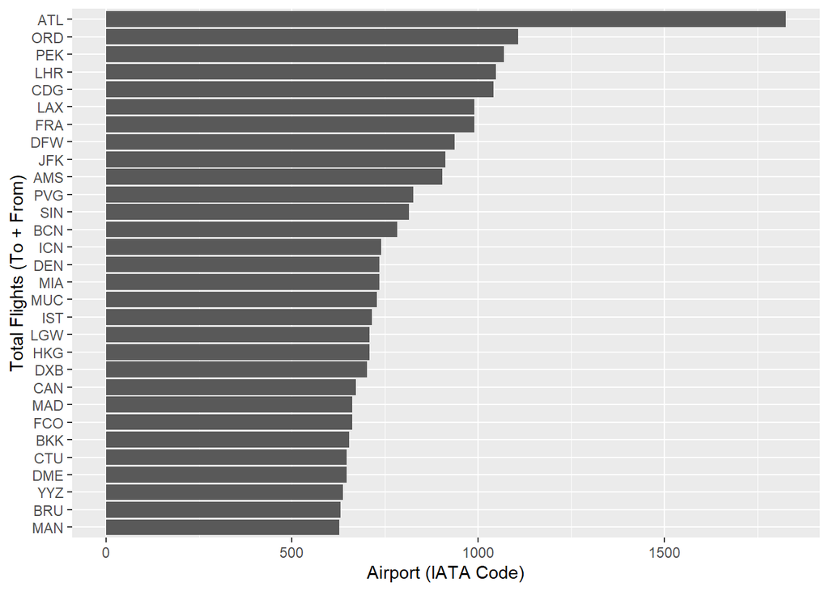

```r
top_airports <- flight_traffic %>% slice_max(flight_traffic, n=30)
ggplot(top_airports, aes(y = reorder(iata, flight_traffic), x = flight_traffic)) + geom_bar(stat = "identity") + labs(
    x = "Airport (IATA Code)",
    y = "Total Flights (To + From)"
  )
```